# Genome assembly with SPAdes

### Extracting data from the contig names

As you should have realized in the last question, the information we are interested in, is ‘hidden’ in the contig names. There are many ways to manipulate pieces of text (“character strings”) in R.

We will show one way to extract the information specifically suitable for this situation, but this is not the only way; feel free to explore! You are also encouraged to at any time run any object to see what is stored in it (e.g., simply run `contigs` to see how the fasta file is stored in R).

First, we can extract the contig names and store them as a separate character string as follows:

```r
contig_names <- names(contigs)
head(contig_names)
```

```
## [1] "NODE_1_length_338569_cov_72.752203" "NODE_2_length_262063_cov_40.549039"
## [3] "NODE_3_length_230198_cov_47.826901" "NODE_4_length_118569_cov_48.155241"
## [5] "NODE_5_length_112130_cov_46.156451" "NODE_6_length_111275_cov_50.587667"
```

Here, we make use of the fact that all our pieces of information are split by an underscore ("_"). That is fortunate, as you can now directly use the R function `strsplit()`:

```r
contig_names_ls <- strsplit(contig_names, split = "_")
head(contig_names_ls)
```

```
## [[1]]
## [1] "NODE"      "1"         "length"    "338569"    "cov"       "72.752203"
##
## [[2]]
## [1] "NODE"      "2"         "length"    "262063"    "cov"       "40.549039"
##
## [[3]]
## [1] "NODE"      "3"         "length"    "230198"    "cov"       "47.826901"
##
## [[4]]
## [1] "NODE"      "4"         "length"    "118569"    "cov"       "48.155241"
##
## [[5]]
## [1] "NODE"      "5"         "length"    "112130"    "cov"       "46.156451"
##
## [[6]]
## [1] "NODE"      "6"         "length"    "111275"    "cov"       "50.587667"
```

As you can see, this has extracted all the characters in between the underscores, per contig name. Now we can store all this information neatly in a matrix:

```r
# this binds all elements of contig_names_ls by rows
contig_names_df_raw <- do.call(rbind, contig_names_ls)
head(contig_names_df_raw)
```

```
##      [,1]   [,2] [,3]     [,4]     [,5]  [,6]
## [1,] "NODE" "1"  "length" "338569" "cov" "72.752203"
## [2,] "NODE" "2"  "length" "262063" "cov" "40.549039"
## [3,] "NODE" "3"  "length" "230198" "cov" "47.826901"
## [4,] "NODE" "4"  "length" "118569" "cov" "48.155241"
## [5,] "NODE" "5"  "length" "112130" "cov" "46.156451"
## [6,] "NODE" "6"  "length" "111275" "cov" "50.587667"
```

where every row is a contig, and the columns contain the information per contig. This is almost a data frame we can work with in R. However, we are only interested in columns 2, 4 and 6. So, we have to select only these, and it is good practice to name them too:

```r
contig_names_df <- data.frame("Node" = contig_names_df_raw[, 2],
                              "Length" = contig_names_df_raw[, 4],
                              "kmer_coverage" = contig_names_df_raw[, 6])
head(contig_names_df)
```

|  | Node | Length | kmer_coverage |
| --- | --- | --- | --- |
| 1 | 1 | 338569 | 72.752203 |
| 2 | 2 | 262063 | 40.549039 |
| 3 | 3 | 230198 | 47.826901 |
| 4 | 4 | 118569 | 48.155241 |
| 5 | 5 | 112130 | 46.156451 |
| 6 | 6 | 111275 | 50.587667 |

That looks good, let’s see some summary statistics on the numbers…

```r
summary(contig_names_df)
```

```
##      Node              Length          kmer_coverage
##  Length:249         Length:249         Length:249
##  Class :character   Class :character   Class :character
##  Mode  :character   Mode  :character   Mode  :character
```

Sometimes, R may have read the contig lengths and coverages as “characters” or “factors”: both a class of text. You can see what this looks like in the example output of the `summary()` above. Instead, we need R to read these variables as “numeric”: numbers. To ensure this happens the same for everyone, we turn the variables first all into characters and then into numerics:

```r
contig_names_df$Length <- as.numeric(as.character(contig_names_df$Length))
contig_names_df$kmer_coverage <- as.numeric(as.character(contig_names_df$kmer_coverage))
summary(contig_names_df)
```

```
##      Node               Length       kmer_coverage
##  Length:249         Min.   :   128   Min.   :   0.7269
##  Class :character   1st Qu.:   383   1st Qu.:   0.9650
##  Mode  :character   Median :   426   Median :  50.2643
##                     Mean   : 12552   Mean   :  85.2727
##                     3rd Qu.:  3952   3rd Qu.:  93.4844
##                     Max.   :338569   Max.   :1897.9916
```

```r
head(contig_names_df)
```

|  | Node | Length | kmer_coverage |
| --- | --- | --- | --- |
| 1 | 1 | 338569 | 72.75220 |
| 2 | 2 | 262063 | 40.54904 |
| 3 | 3 | 230198 | 47.82690 |
| 4 | 4 | 118569 | 48.15524 |
| 5 | 5 | 112130 | 46.15645 |
| 6 | 6 | 111275 | 50.58767 |

#### Exercise 5.2.2: Extracting the contig quality data

> Remember to write and save your code in your R script “contig_filtering.R”!

##### Question

1. Make a data frame as the one above for your own data.
2. Describe along every line of code in your script what it does with comments (using `#`).

##### Answer

```r
# extract fasta headers.
contig_names <- names(contigs)
# split each header by underscore; produces a list.
contig_names_ls <- strsplit(contig_names, split = "_")
# bind all the rows in the list.
contig_names_df_raw <- do.call(rbind, contig_names_ls)
# make a named data frame of the 2nd, ...
contig_names_df <- data.frame("Node" = contig_names_df_raw[, 2],
                              #     ...4th ...
                              "Length" = contig_names_df_raw[, 4],
                              #     ...and 6th column.
                              "kmer_coverage" = contig_names_df_raw[, 6])
# read contig lengths as numeric.
contig_names_df$Length <- as.numeric(as.character(contig_names_df$Length))
# read k-mer coverage as numeric.
contig_names_df$kmer_coverage <- as.numeric(as.character(contig_names_df$kmer_coverage))
```

### Plotting the contigs

At last, you should now have obtained a neat data frame with one row per contig, where the columns indicate the contig length and k-mer coverage. Time to explore this data. Here are two ways to make the same scatter plot, where every point is a contig:

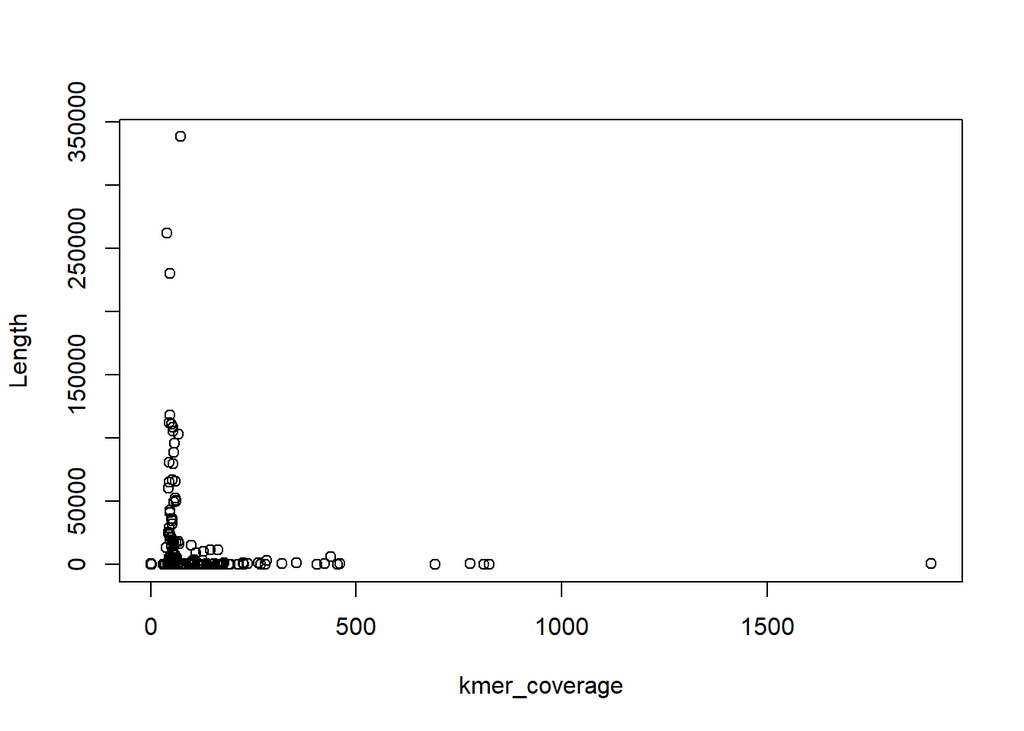

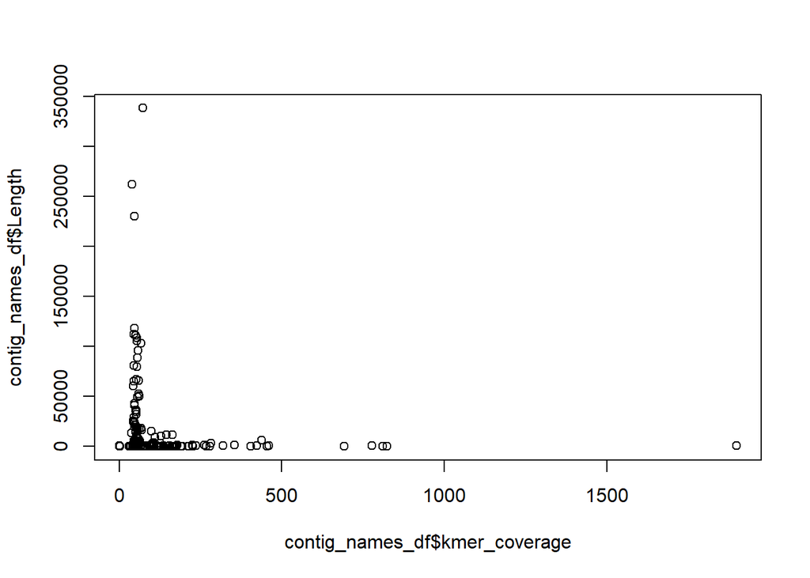

```r
plot(Length ~ kmer_coverage,
     data = contig_names_df)
plot(x = contig_names_df$kmer_coverage,
     y = contig_names_df$Length)
```

You can use either way of coding, just a matter of personal preference. We will continue using the former here, but feel free to use the latter if you prefer.

For the contigs with smaller values it is difficult to see their exact coordinates on either axis in this example, because the axes are “stretched” by a few extremely high values. This can easily be fixed by a log-transformation for both the x- and y-axis:

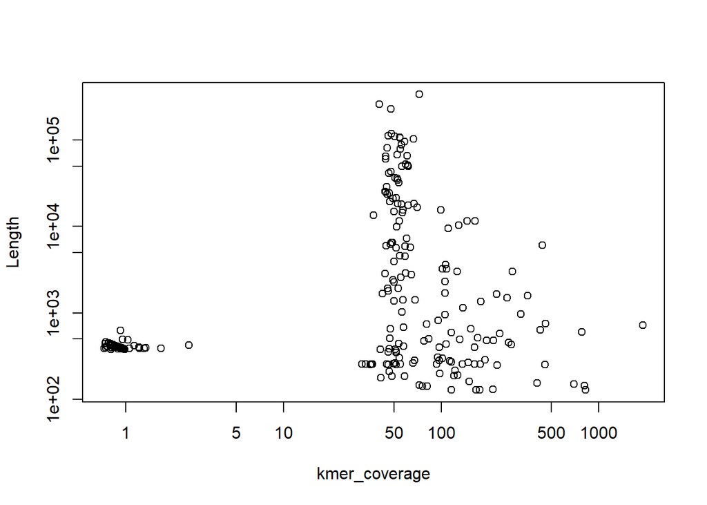

```r
plot(Length ~ kmer_coverage,
     data = contig_names_df,
     log = 'xy')
```

This is arguably not the best layout of a plot you might have come across in your life and R contains almost infinite ways to customize plots. Remember though, that in a scientific setting it is only desirable to add features to a plot if they help in its interpretation. However, feel free to play around here, of course. These are just some options; simply play around or Google for more:

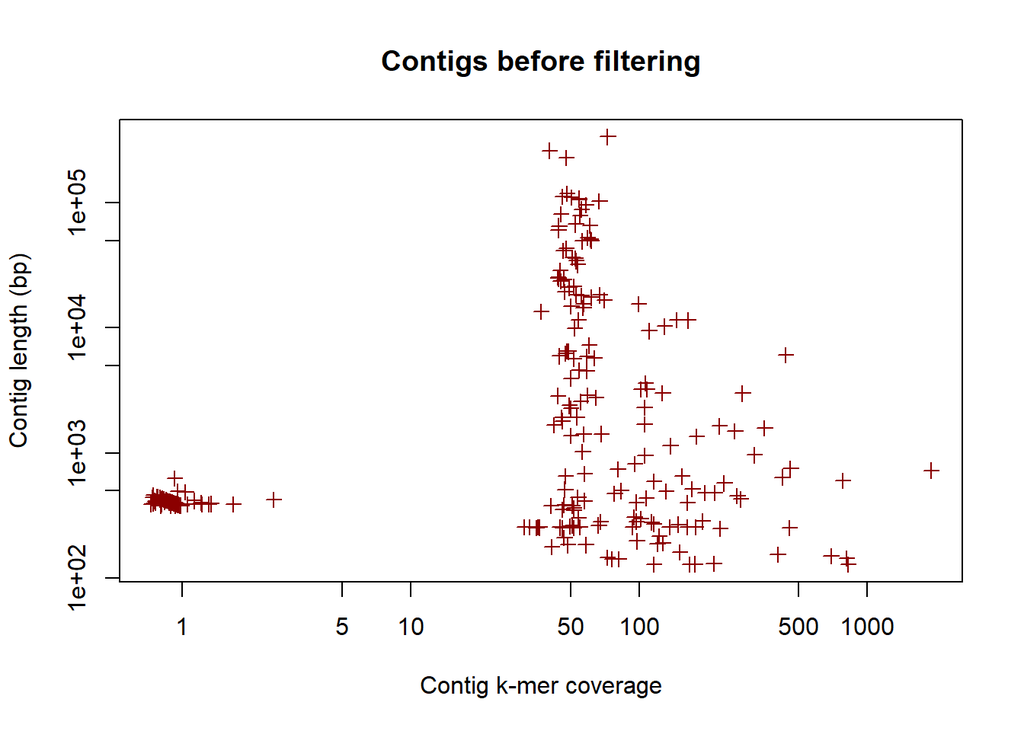

```r
plot(Length ~ kmer_coverage,
     data = contig_names_df,
     log = 'xy',
     col = "darkred",
     pch = 3,
     main = "Contigs before filtering",
     ylab = "Contig length (bp)",
     xlab = "Contig k-mer coverage")
```

Now the real question is of course: which contigs are informative, or “good”, and which are not?

#### Adding filtering parameters

Again:

> As a rule of thumb, for an assembly done with a decent amount of reads, you should have a minimum k-mer coverage of 10. Any contigs with extremely low coverage (<10) should be removed. Likewise, short contiges (<500bp) should be removed (even if they have a high coverage), since they are unlikely to provide any useful information.

So, let’s add that information to the plot below. In addition, we show a way to also plot the contig / Node numbers with the `text()` function.

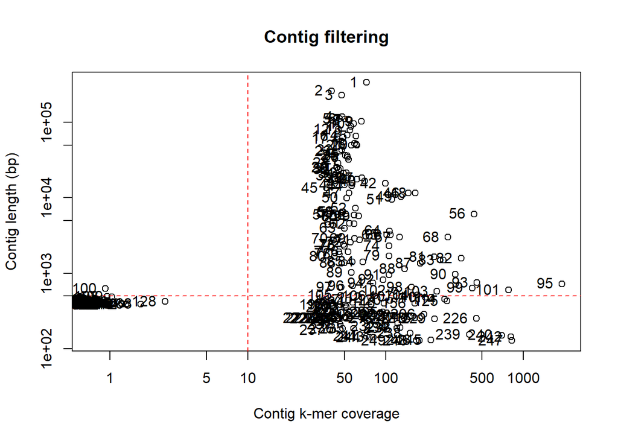

```r
plot(Length ~ kmer_coverage,
     data = contig_names_df,
     log = 'xy',
     main = "Contig filtering",
     ylab = "Contig length (bp)",
     xlab = "Contig k-mer coverage")
abline(v = 10, lty = 2, col = "red")  # draw vertical line at v; lty = line type
abline(h = 500, lty = 2, col = "red") # draw horizontal line at h
text(Length ~ kmer_coverage,
     data = contig_names_df,
     labels = Node,                   # pos 1, 2, 3 or 4 mean respectively
     pos = 2)                         # below, left, above, right of data point
```

#### `ggplot2`: an R plotting package

A popular plotting package in R is `ggplot2`. It is relatively easy to use to make plots with a more advanced layout.

Install the package by running:

```r
install.packages("ggplot2")
```

Now load the package with:

```r
library(ggplot2)
```

ggplot always first requires us to specify the data set and parameters to be plotted with a call to the `ggplot()` function. Subsequently, we can add “layers” of information to the plot with `+`, e.g. a layer that adds the data as “points”:

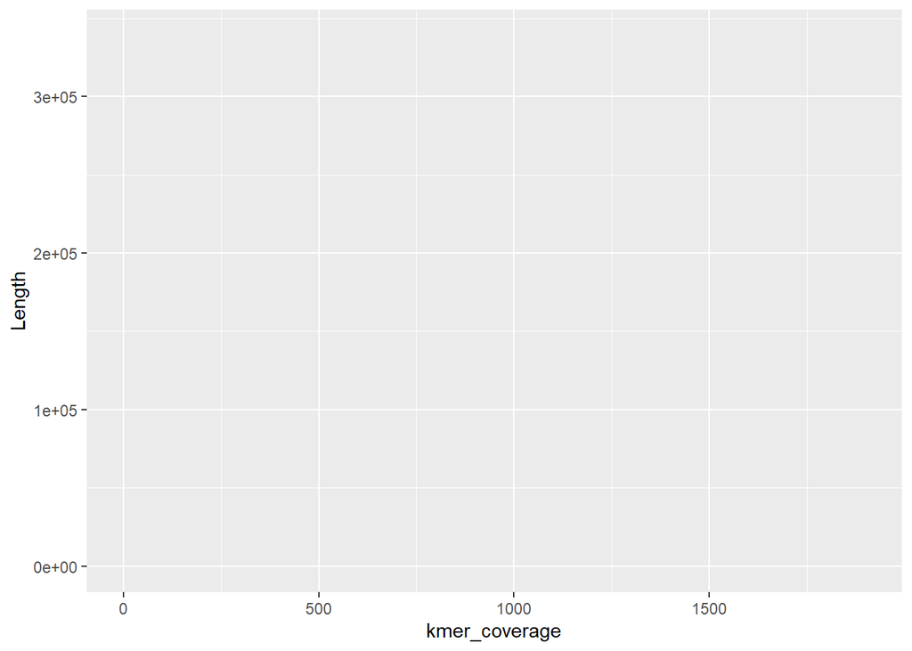

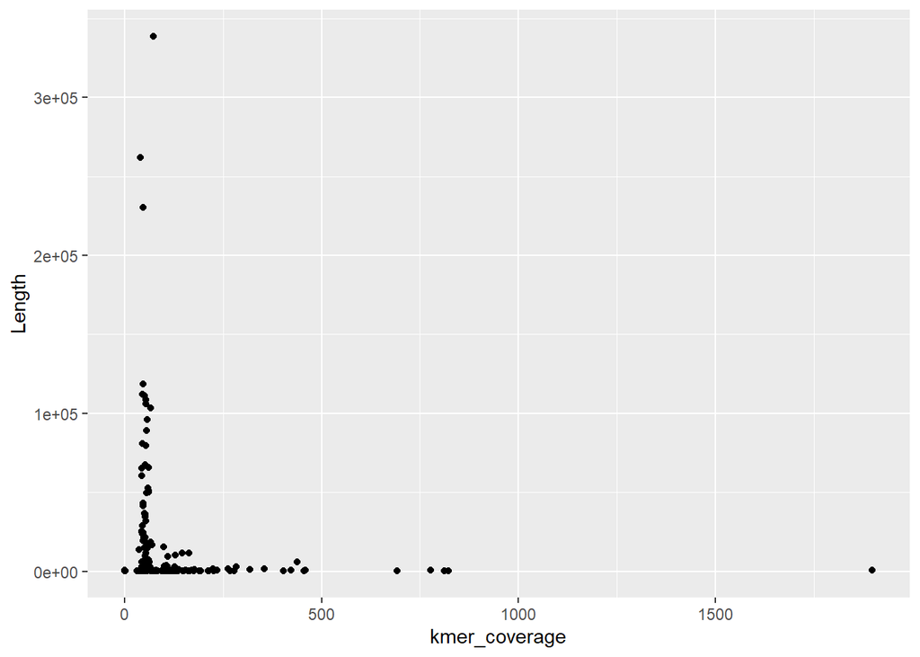

```r
ggplot(data = contig_names_df,          # first argument specifies the
                                        # data frame to use
       mapping = aes(x = kmer_coverage, # the mapping tells ggplot which
                                        # variables from data...
                     y = Length))       #    ...to put on the x- and y-axis
                                        # (i.e., aesthetics)

ggplot(data = contig_names_df,
       mapping = aes(x = kmer_coverage,
                     y = Length)) +
  geom_point()                          # add a layer with point geometries
```

Naturally, we can add much more information to our plot, mostly by coding more “layers”. In addition, ggplot contains a set of pre-defined ‘themes’ for specific layouts; we added the “bw theme” here, for instance.

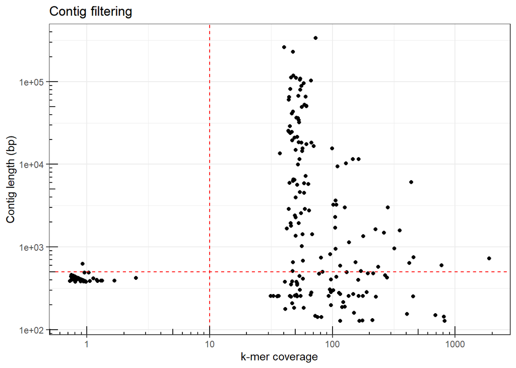

```r
ggplot(contig_names_df,
       aes(kmer_coverage,
           Length)) +
  geom_point() +
  geom_vline(xintercept = 10, lty = 2, col = "red") +  # adds vertical line
  geom_hline(yintercept = 500, lty = 2, col = "red") + # adds horizontal line
  scale_x_log10() +                                # sets x-axis to log10 scale
  scale_y_log10() +                                # sets y-axis to log10 scale
  annotation_logticks() +                          # adds log10 ticks
  labs(title = "Contig filtering",
       x = "k-mer coverage",
       y = "Contig length (bp)") +
  theme_bw()                                       # adds bw theme layout
```

To easily adjust the labels on the y-axis, this package can prove useful (install first if necessary):

```r
#install.packages("scales")
library(scales)
```

Now we can for example also add the Node numbers as labels (besides or instead of the points) and add a caption. Notice how the y-axis labels and the theme have also changed in the plot below:

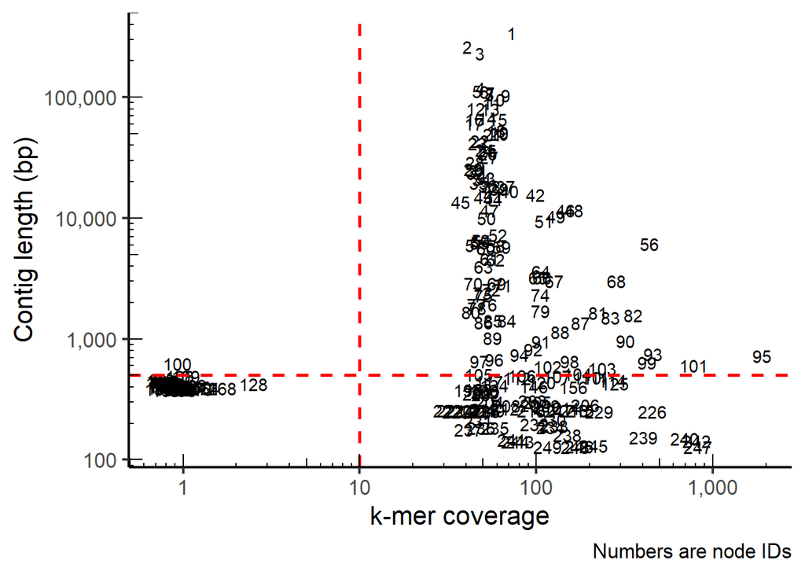

```r
ggplot(contig_names_df,
       aes(kmer_coverage,
           Length,
           label = Node)) +
  geom_text() +
  geom_vline(xintercept = 10, lty = 2, col = "red", size = 1) +
  geom_hline(yintercept = 500, lty = 2, col = "red", size = 1) +
  scale_x_log10(labels = label_comma(accuracy = 1)) +
  scale_y_log10(labels = label_comma(accuracy = 1)) +
  annotation_logticks() +
  labs(x = "k-mer coverage",
       y = "Contig length (bp)",
       caption = "Numbers are node IDs") +
  theme_classic(base_size = 16)
```

There are many, many more ways to customize both ggplot and R base plots, but that is beyond the scope of this tutorial.

#### Exercise 5.2.3: Plotting contigs and understanding basics

> Remember to write and save your code in your R script “contig_filtering.R”!

##### Question 1

- In the examples above we show the use of the arguments `col`, `pch`, `main`, `lty`, `size` and `base_size`, among others. Describe for each of these what they mean or do. (Hint: If you don’t know, you can just play around with the values and see what changes.)

##### Answer

```r
## They are used to change plot aesthetics, respectively:
# col = color
# pch = symbol (see ?points() for complete list)
# main = plot title
# lty = line type
# size = line (or point) size / width / thickness
# base_size = base font size for whole plot
```

##### Question 2

- Make a plot like the ones above for your contigs, using the data frame you created in the last question. You can either use the base R plot function, or ggplot, as you prefer.
- Describe along every line of code what it does with comments (using `#`).

##### Answer

```r
# e.g.
ggplot(contig_names_df, aes(kmer_coverage, Length, label = Node)) +
  geom_text() +
  geom_vline(xintercept = 10, lty = 2, col = "red") +
  geom_hline(yintercept = 500, lty = 2, col = "red") +
  scale_x_log10(labels = comma) +
  scale_y_log10(labels = comma) +
  annotation_logticks() +
  labs(x = "k-mer coverage",
       y = "Contig length (bp)",
       caption = "Numbers are node IDs") +
  theme_classic(base_size = 16)
```

##### Question 3

- How many, and which, contigs will you keep? How many will you discard?
- So what is the percentage of contigs you will retain? Is this along your expectations? Why (not)?

##### Answer

```r
# depends on your file
# you are keeping the contigs in the upper right quadrant
# so count how many those are and divide by the total number of contigs
```

Try it and check with your assistant that you got it right!

## 5.3 Filter contigs and write to fasta file

You should now have seen which contigs you want to keep for your further downstream analysis. The last step in this tutorial is to select those contigs, and again write them to a new fasta file.

First, ask R which contigs are in line with your parameter cut-offs and cross-check with your plot:

```r
selection_IDs <- contig_names_df$Length >= 500 & # note the & operator here
                 contig_names_df$kmer_coverage >= 10
selection_IDs
```

```
##   [1]  TRUE  TRUE  TRUE  TRUE  TRUE  TRUE  TRUE  TRUE  TRUE  TRUE  TRUE  TRUE
##  [13]  TRUE  TRUE  TRUE  TRUE  TRUE  TRUE  TRUE  TRUE  TRUE  TRUE  TRUE  TRUE
##  [25]  TRUE  TRUE  TRUE  TRUE  TRUE  TRUE  TRUE  TRUE  TRUE  TRUE  TRUE  TRUE
##  [37]  TRUE  TRUE  TRUE  TRUE  TRUE  TRUE  TRUE  TRUE  TRUE  TRUE  TRUE  TRUE
##  [49]  TRUE  TRUE  TRUE  TRUE  TRUE  TRUE  TRUE  TRUE  TRUE  TRUE  TRUE  TRUE
##  [61]  TRUE  TRUE  TRUE  TRUE  TRUE  TRUE  TRUE  TRUE  TRUE  TRUE  TRUE  TRUE
##  [73]  TRUE  TRUE  TRUE  TRUE  TRUE  TRUE  TRUE  TRUE  TRUE  TRUE  TRUE  TRUE
##  [85]  TRUE  TRUE  TRUE  TRUE  TRUE  TRUE  TRUE  TRUE  TRUE  TRUE  TRUE  TRUE
##  [97]  TRUE  TRUE  TRUE FALSE  TRUE  TRUE  TRUE  TRUE  TRUE FALSE FALSE FALSE
## [109] FALSE FALSE FALSE FALSE FALSE FALSE FALSE FALSE FALSE FALSE FALSE FALSE
## [121] FALSE FALSE FALSE FALSE FALSE FALSE FALSE FALSE FALSE FALSE FALSE FALSE
## [133] FALSE FALSE FALSE FALSE FALSE FALSE FALSE FALSE FALSE FALSE FALSE FALSE
## [145] FALSE FALSE FALSE FALSE FALSE FALSE FALSE FALSE FALSE FALSE FALSE FALSE
## [157] FALSE FALSE FALSE FALSE FALSE FALSE FALSE FALSE FALSE FALSE FALSE FALSE
## [169] FALSE FALSE FALSE FALSE FALSE FALSE FALSE FALSE FALSE FALSE FALSE FALSE
## [181] FALSE FALSE FALSE FALSE FALSE FALSE FALSE FALSE FALSE FALSE FALSE FALSE
## [193] FALSE FALSE FALSE FALSE FALSE FALSE FALSE FALSE FALSE FALSE FALSE FALSE
## [205] FALSE FALSE FALSE FALSE FALSE FALSE FALSE FALSE FALSE FALSE FALSE FALSE
## [217] FALSE FALSE FALSE FALSE FALSE FALSE FALSE FALSE FALSE FALSE FALSE FALSE
## [229] FALSE FALSE FALSE FALSE FALSE FALSE FALSE FALSE FALSE FALSE FALSE FALSE
## [241] FALSE FALSE FALSE FALSE FALSE FALSE FALSE FALSE FALSE
```

```r
which(selection_IDs) # which are TRUE?
```

```
##   [1]   1   2   3   4   5   6   7   8   9  10  11  12  13  14  15  16  17  18
##  [19]  19  20  21  22  23  24  25  26  27  28  29  30  31  32  33  34  35  36
##  [37]  37  38  39  40  41  42  43  44  45  46  47  48  49  50  51  52  53  54
##  [55]  55  56  57  58  59  60  61  62  63  64  65  66  67  68  69  70  71  72
##  [73]  73  74  75  76  77  78  79  80  81  82  83  84  85  86  87  88  89  90
##  [91]  91  92  93  94  95  96  97  98  99 101 102 103 104 105
```

Now select only those contigs and store them in a new object:

```r
contigs_selected <- contigs[selection_IDs]
contigs_selected
```

```
## DNAStringSet object of length 104:
##        width seq                                            names
##   [1] 338569 ATGAGCTTGATTACTTTAGTCT...AGACAGTGGCAGGCGCCTGCG NODE_1_length_338...
##   [2] 262063 GGGTGTTAGTCTGAGAGTGGGT...TCTGGGGTGGTGATCGCGTTT NODE_2_length_262...
##   [3] 230198 CGGCCGTGAATGACCGCACAGG...TCGGGTGATAGGCGTGGCAAA NODE_3_length_230...
##   [4] 118569 TACGAATATCAACCAACACATC...TACGTCTGGGACGATGGTTCA NODE_4_length_118...
##   [5] 112130 ACTCGTTCGACTTGCATGTATT...TTTATCAGACATAATTAAGTG NODE_5_length_112...
##   ...    ... ...
## [100]    600 AGGCGTGGCAAAAGTAAACCGG...TGGCGCAGTAATCACCTTCAG NODE_101_length_6...
## [101]    590 TGACTGTCTGAGTAACAGAACT...TTATCAGGAGCTGCTTGTGAA NODE_102_length_5...
## [102]    572 AGAAGCAAGCTTCTCGGTTTGG...TACGACTTCACCCTAATCATT NODE_103_length_5...
## [103]    513 ATTATAGCTAATATCACCTTTC...TCCCATGGCCATTATAACCTT NODE_104_length_5...
## [104]    510 CGGCATCAAGACAGATAAACGA...TGATATTATGGTCTGGTATTC NODE_105_length_5...
```

Lastly, write this object to a fasta file, using the `writeXStringSet()` function from the `Biostrings` package that was still loaded from earlier on in the tutorial:

```r
# using relative path
## write to your current working directory, which you can check with getwd()
writeXStringSet(contigs_selected, filepath = "03_<ESL0xxx>_contigs_filtered.fasta")
# using absolute path
# * do not break your path into a separate line
writeXStringSet(contigs_selected,
                filepath = "path/where/to/save/03_<ESL0xxx>_contigs_filtered.fasta")
```

### Exercise 5.3.1: Contig selection and write to fasta file

> Remember to write and save your code in your R script “contig_filtering.R”!

#### Question 1

- Make code to select…
  - …only contigs *smaller* than 400 bp.
  - …only contigs with a k-mer coverage *between* 20 and 100.
  - …*bonus*: only contigs *longer than* 500 bp *OR* with a k-mer coverage *of at least* 10. (Hint: whereas the AND operator is `&`, the OR operator is `|`.)

#### Answer

```r
# take note of correct application of <, >, <=, >=, & and |
# e.g.:
contigs[contig_names_df$Length < 400]
contigs[contig_names_df$kmer_coverage >= 20 &
        contig_names_df$kmer_coverage <= 100]
contigs[contig_names_df$Length > 500 | contig_names_df$kmer_coverage >= 10]
```

#### Question 2

- Make your contig selection and write it to a new fasta file, called "03__contigs_selected.fasta", like in the example above.
- Upload this file to your working directory on the cluster again, using the `scp` command.

#### Answer

```r
selection_IDs <- contig_names_df$Length > 500 &
                 contig_names_df$kmer_coverage > 10
contigs_selected <- contigs[selection_IDs]
writeXStringSet(contigs_selected, "03_<ESL0xxx>_contigs_filtered.fasta")
```

```bash
# Put the command on the same line. Text is wrapped for visibility!
scp /path/to/03_<ESL0xxx>_contigs_filtered.fasta
      <yourusername>@curnagl.dcsr.unil.ch:<path/to/copy/to>
```